# IODS course project

# chapter 4 clustering and classification

```r
date()
```

```
## [1] "Thu Dec 09 10:00:59 2021"
```

## The diary for this chapter, clustering and classification

## Analysis exercises

- 1 Load the Boston data from the MASS package

```r
# 1 Load the Boston data from the MASS package
# The full R scripts gave in my github page the 'Ex4_cluster and classification.R'
```

- 2 Show a graphical overview of the data

```r
# Load the library
library(MASS)
```

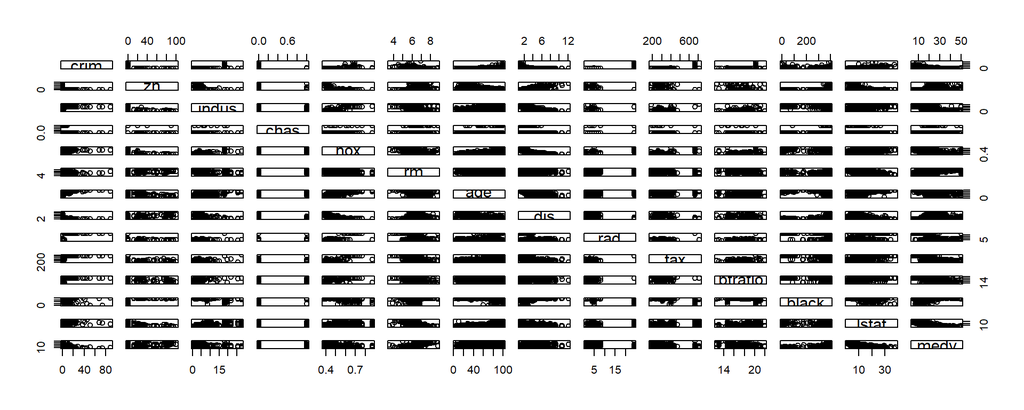

```r
library(ggplot2)
library(GGally)
# Load the Boston data from the MASS package
data("Boston") #506*14
# Show a graphical overview of the data
pairs(Boston)
```

[figure not shown]

```r
p <- ggpairs(Boston,
             lower = list(combo = wrap("facethist", bins = 20)))
p
```

- 3 Standardize the dataset and print out summaries of the scaled data
- Now all column have been scaled

```
##       crim                 zn               indus              chas
##  Min.   :-0.419367   Min.   :-0.48724   Min.   :-1.5563   Min.   :-0.2723
##  1st Qu.:-0.410563   1st Qu.:-0.48724   1st Qu.:-0.8668   1st Qu.:-0.2723
##  Median :-0.390280   Median :-0.48724   Median :-0.2109   Median :-0.2723
##  Mean   : 0.000000   Mean   : 0.00000   Mean   : 0.0000   Mean   : 0.0000
##  3rd Qu.: 0.007389   3rd Qu.: 0.04872   3rd Qu.: 1.0150   3rd Qu.:-0.2723
##  Max.   : 9.924110   Max.   : 3.80047   Max.   : 2.4202   Max.   : 3.6648
##       nox                rm               age               dis
##  Min.   :-1.4644   Min.   :-3.8764   Min.   :-2.3331   Min.   :-1.2658
##  1st Qu.:-0.9121   1st Qu.:-0.5681   1st Qu.:-0.8366   1st Qu.:-0.8049
##  Median :-0.1441   Median :-0.1084   Median : 0.3171   Median :-0.2790
##  Mean   : 0.0000   Mean   : 0.0000   Mean   : 0.0000   Mean   : 0.0000
##  3rd Qu.: 0.5981   3rd Qu.: 0.4823   3rd Qu.: 0.9059   3rd Qu.: 0.6617
##  Max.   : 2.7296   Max.   : 3.5515   Max.   : 1.1164   Max.   : 3.9566
##       rad               tax             ptratio            black
##  Min.   :-0.9819   Min.   :-1.3127   Min.   :-2.7047   Min.   :-3.9033
##  1st Qu.:-0.6373   1st Qu.:-0.7668   1st Qu.:-0.4876   1st Qu.: 0.2049
##  Median :-0.5225   Median :-0.4642   Median : 0.2746   Median : 0.3808
##  Mean   : 0.0000   Mean   : 0.0000   Mean   : 0.0000   Mean   : 0.0000
##  3rd Qu.: 1.6596   3rd Qu.: 1.5294   3rd Qu.: 0.8058   3rd Qu.: 0.4332
##  Max.   : 1.6596   Max.   : 1.7964   Max.   : 1.6372   Max.   : 0.4406
##      lstat              medv
##  Min.   :-1.5296   Min.   :-1.9063
##  1st Qu.:-0.7986   1st Qu.:-0.5989
##  Median :-0.1811   Median :-0.1449
##  Mean   : 0.0000   Mean   : 0.0000
##  3rd Qu.: 0.6024   3rd Qu.: 0.2683
##  Max.   : 3.5453   Max.   : 2.9865
```

- 4 Fit the linear discriminant analysis

```
## crime
## [-0.419,-0.411]  (-0.411,-0.39] (-0.39,0.00739]  (0.00739,9.92]
##             127             126             126             127
```

```
## Call:
## lda(crime ~ ., data = train)
##
## Prior probabilities of groups:
## [-0.419,-0.411]  (-0.411,-0.39] (-0.39,0.00739]  (0.00739,9.92]
##       0.2500000       0.2450495       0.2450495       0.2599010
##
## Group means:
##                         zn      indus         chas        nox         rm
## [-0.419,-0.411]  0.9285544 -0.8729520 -0.116404306 -0.8591683  0.3971562
## (-0.411,-0.39]  -0.1191032 -0.2757627  0.006051757 -0.5500237 -0.1752439
## (-0.39,0.00739] -0.3815632  0.1746515  0.165126514  0.3375372  0.2178032
## (0.00739,9.92]  -0.4872402  1.0170492 -0.047351911  1.0406720 -0.4504873
##                        age        dis        rad        tax     ptratio
## [-0.419,-0.411] -0.8817918  0.7979490 -0.7044198 -0.7339190 -0.41438352
## (-0.411,-0.39]  -0.3358103  0.3319865 -0.5607666 -0.4896250 -0.07744066
## (-0.39,0.00739]  0.4062402 -0.3435777 -0.4018374 -0.2884284 -0.23794112
## (0.00739,9.92]   0.8117508 -0.8427836  1.6388211  1.5145512  0.78158339
##                       black       lstat        medv
## [-0.419,-0.411]  0.37924474 -0.74577673  0.47925822
## (-0.411,-0.39]   0.31208908 -0.12337704 -0.02388524
## (-0.39,0.00739]  0.07941643 -0.04826725  0.25068516
## (0.00739,9.92]  -0.74509311  0.91412095 -0.63150796
##
## Coefficients of linear discriminants:
##                 LD1          LD2         LD3
## zn       0.06408448  0.818204782 -0.91930251
## indus    0.03670801 -0.252299139  0.33260752
## chas    -0.07716647 -0.063194039  0.14146916
## nox      0.44848287 -0.747288248 -1.37797916
## rm      -0.08248539 -0.184560244 -0.25148930
## age      0.22700359 -0.417172452 -0.06344253
## dis      0.05342562 -0.512879295  0.22025700
## rad      3.12471256  1.010047253  0.11961523
## tax      0.05202837 -0.129714387  0.31976631
## ptratio  0.12235456 -0.017604174 -0.33695806
## black   -0.09893584  0.007572123  0.08095116
## lstat    0.26128112 -0.319161189  0.31666862
## medv     0.25107676 -0.500955211 -0.24636735
##
## Proportion of trace:
##    LD1    LD2    LD3
## 0.9494 0.0378 0.0128
```

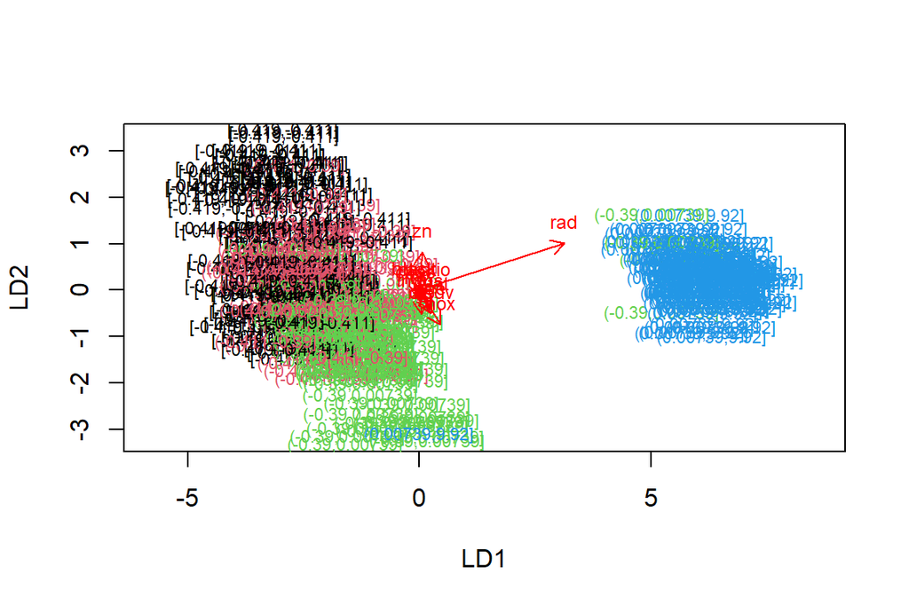

```
##                  predicted
## correct           [-0.419,-0.411] (-0.411,-0.39] (-0.39,0.00739] (0.00739,9.92]
##   [-0.419,-0.411]              14             11               1              0
##   (-0.411,-0.39]                5             17               5              0
##   (-0.39,0.00739]               1              9              16              1
##   (0.00739,9.92]                0              0               0             22
```

```
## [1] 0.6764706
```

- 7 re-paractice the k-means clustering
1. identify the optimal number of clusters by silhouette width, k=2
2. implement k-means algorithm
3. visualize the clusters
4. interpret the results: 177 for cluster 1; 329 for cluster 2.

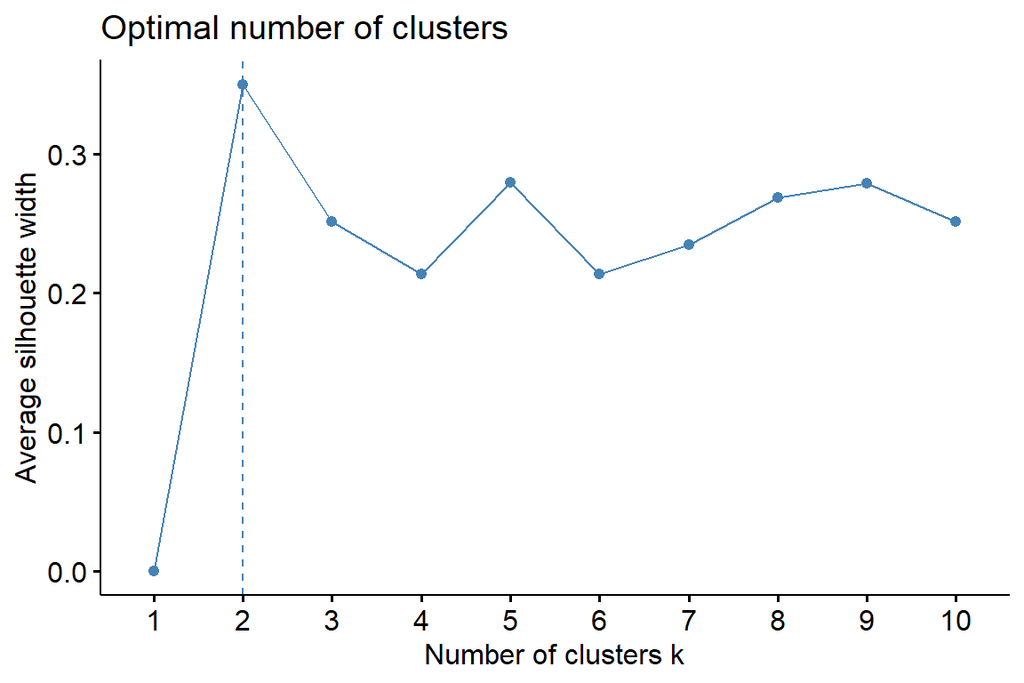

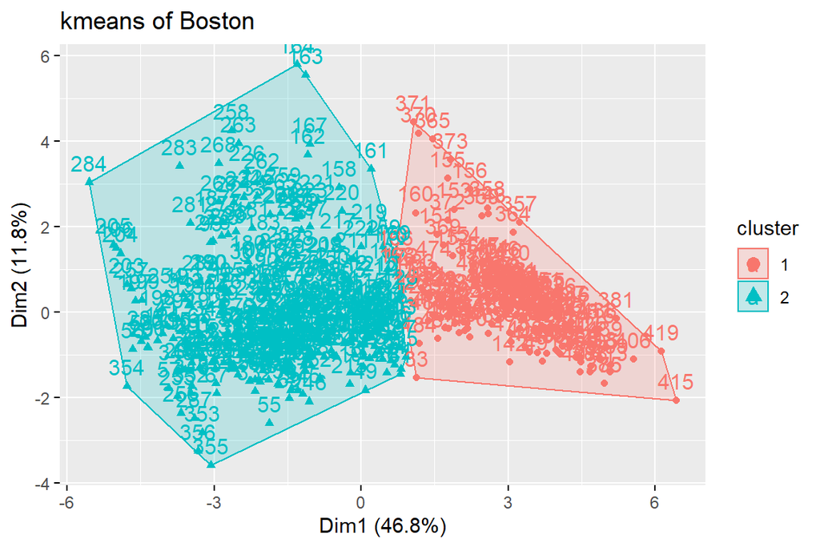

```
##
##   1   2
## 177 329
```

- 8 Bonus
1. Perform k-means on the original Boston data
2. with some reasonable number of clusters

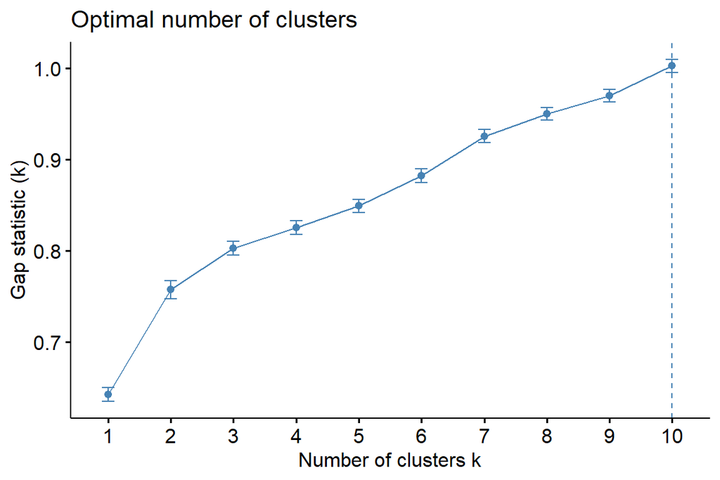

```
## 'data.frame':    506 obs. of  15 variables:
##  $ crim   : num  -0.419 -0.417 -0.417 -0.416 -0.412 ...
##  $ zn     : num  0.285 -0.487 -0.487 -0.487 -0.487 ...
##  $ indus  : num  -1.287 -0.593 -0.593 -1.306 -1.306 ...
##  $ chas   : num  -0.272 -0.272 -0.272 -0.272 -0.272 ...
##  $ nox    : num  -0.144 -0.74 -0.74 -0.834 -0.834 ...
##  $ rm     : num  0.413 0.194 1.281 1.015 1.227 ...
##  $ age    : num  -0.12 0.367 -0.266 -0.809 -0.511 ...
##  $ dis    : num  0.14 0.557 0.557 1.077 1.077 ...
##  $ rad    : num  -0.982 -0.867 -0.867 -0.752 -0.752 ...
##  $ tax    : num  -0.666 -0.986 -0.986 -1.105 -1.105 ...
##  $ ptratio: num  -1.458 -0.303 -0.303 0.113 0.113 ...
##  $ black  : num  0.441 0.441 0.396 0.416 0.441 ...
##  $ lstat  : num  -1.074 -0.492 -1.208 -1.36 -1.025 ...
##  $ medv   : num  0.16 -0.101 1.323 1.182 1.486 ...
##  $ clas   : Factor w/ 4 levels "1","2","3","4": 3 4 3 3 3 4 4 4 4 4 ...
```

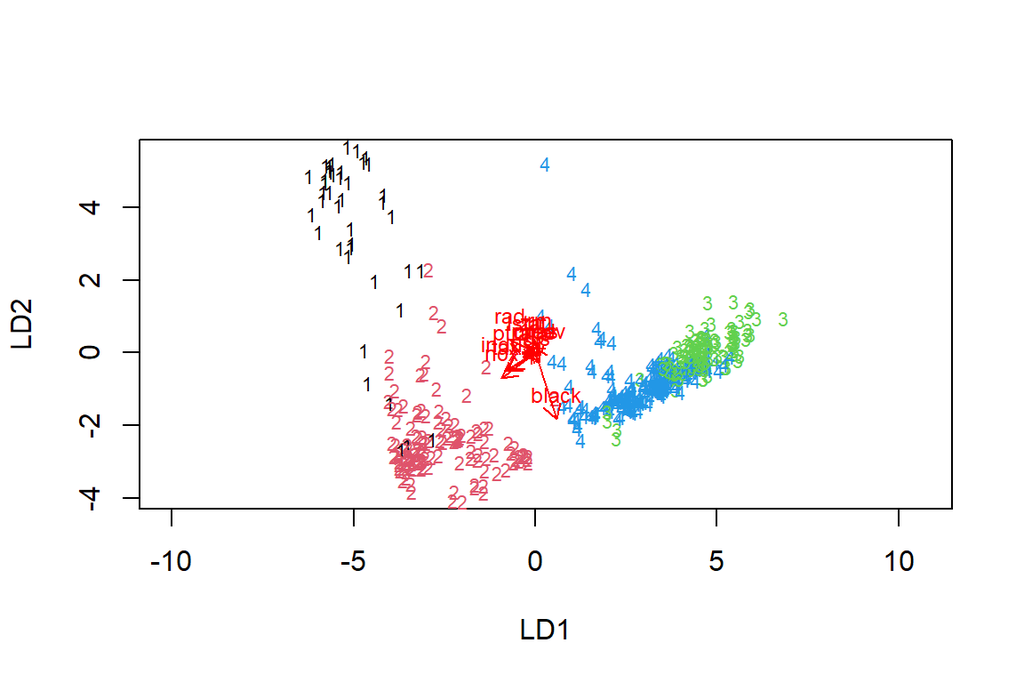

-9 No Super-Bonus